# MNAR sensitivity analysis of internal validation

# 1 Overview

## 1.1 Aims

This report assesses how sensitive the internal-validation results for the existing prediction model are to departures from the missing-at-random (MAR) assumption for three continuous baseline predictors: systolic blood pressure (SBP), non-HDL cholesterol and body mass index (BMI). In particular, it asks how calibration and discrimination would change if the values that were originally missing were systematically lower or higher than their imputed (from multiple imputation procedure) values at the model validation stage.

## 1.2 Methods

For each variable in isolation, missing values were shifted from their imputed values by delta = -0.50, -0.25, +0.25 or +0.50 times the standard deviation of the observed values for that variable and sex. Values originally observed, and the other predictors, were unchanged. The existing model and baseline hazard were held fixed, i.e., no new prediction model was developed. For each scenario, the adjusted predictor values were used to recalculate predicted 10-year risk. The existing counterfactual survival outcomes from the main internal validation were retained, before calculating calibration and discrimination. This sensitivity analysis was carried out in a single imputation chain, given the small variance in results across the imputation chains in the main analysis. Results are compared against performance when the multiply imputed values are used, i.e., aligned with the main internal validation, where delta = 0.

## 1.3 Summary

This MNAR sensitivity analysis had a minimal impact on calibration and discrimination. See change in whole cohort performance relative to the main analysis. This reinforces the validity of findings given the potential risk of the MAR assumption not holding (see supplementary data file 6).

# 2 Entire cohort validation

## 2.1 Metrics

The reference is the results from the main internal-validation for imputation stream 1, where there is no change from the imputed values. Each MNAR scenario changes adjusts (by delta) of one predictor (SBP, non-HDL cholesterol, BMI) at a time. Only values which were originally missing are adjusting (i.e. observed values are still used).

Whole-cohort performance under MAR and MNAR scenarios

| Gender | Variable | Scenario | ICI | E50 | E90 | C-statistic |
| --- | --- | --- | --- | --- | --- | --- |
| Female | Systolic blood pressure | 0 SD (main) | 0.001 | 0.000 | 0.002 | 0.875 |
| Female | Systolic blood pressure | -0.50 SD | 0.001 | 0.000 | 0.003 | 0.875 |
| Female | Systolic blood pressure | -0.25 SD | 0.001 | 0.000 | 0.002 | 0.875 |
| Female | Systolic blood pressure | +0.25 SD | 0.000 | 0.000 | 0.002 | 0.875 |
| Female | Systolic blood pressure | +0.50 SD | 0.000 | 0.000 | 0.001 | 0.875 |
| Female | Non-HDL cholesterol | 0 SD (main) | 0.001 | 0.000 | 0.002 | 0.875 |
| Female | Non-HDL cholesterol | -0.50 SD | 0.002 | 0.000 | 0.006 | 0.875 |
| Female | Non-HDL cholesterol | -0.25 SD | 0.001 | 0.000 | 0.004 | 0.875 |
| Female | Non-HDL cholesterol | +0.25 SD | 0.000 | 0.000 | 0.001 | 0.875 |
| Female | Non-HDL cholesterol | +0.50 SD | 0.001 | 0.001 | 0.001 | 0.875 |
| Female | Body mass index | 0 SD (main) | 0.001 | 0.000 | 0.002 | 0.875 |
| Female | Body mass index | -0.50 SD | 0.001 | 0.000 | 0.003 | 0.875 |
| Female | Body mass index | -0.25 SD | 0.001 | 0.000 | 0.002 | 0.875 |
| Female | Body mass index | +0.25 SD | 0.001 | 0.000 | 0.002 | 0.875 |
| Female | Body mass index | +0.50 SD | 0.000 | 0.000 | 0.001 | 0.875 |
| Male | Systolic blood pressure | 0 SD (main) | 0.001 | 0.000 | 0.002 | 0.859 |
| Male | Systolic blood pressure | -0.50 SD | 0.001 | 0.000 | 0.004 | 0.859 |
| Male | Systolic blood pressure | -0.25 SD | 0.001 | 0.000 | 0.003 | 0.859 |
| Male | Systolic blood pressure | +0.25 SD | 0.001 | 0.001 | 0.002 | 0.858 |
| Male | Systolic blood pressure | +0.50 SD | 0.001 | 0.000 | 0.001 | 0.858 |
| Male | Non-HDL cholesterol | 0 SD (main) | 0.001 | 0.000 | 0.002 | 0.859 |
| Male | Non-HDL cholesterol | -0.50 SD | 0.003 | 0.001 | 0.009 | 0.859 |
| Male | Non-HDL cholesterol | -0.25 SD | 0.002 | 0.000 | 0.005 | 0.859 |
| Male | Non-HDL cholesterol | +0.25 SD | 0.001 | 0.001 | 0.001 | 0.859 |
| Male | Non-HDL cholesterol | +0.50 SD | 0.002 | 0.002 | 0.004 | 0.858 |
| Male | Body mass index | 0 SD (main) | 0.001 | 0.000 | 0.002 | 0.859 |
| Male | Body mass index | -0.50 SD | 0.001 | 0.000 | 0.004 | 0.859 |
| Male | Body mass index | -0.25 SD | 0.001 | 0.000 | 0.003 | 0.859 |
| Male | Body mass index | +0.25 SD | 0.001 | 0.001 | 0.002 | 0.859 |
| Male | Body mass index | +0.50 SD | 0.001 | 0.001 | 0.001 | 0.859 |

Differences below are calculated as MNAR scenario minus the sex-specific MAR reference. Therefore, a positive difference in ICI, E50 or E90 indicates worse calibration; a negative difference in the C-statistic indicates worse discrimination.

Change in whole-cohort performance relative to main analysis (delta = 0)

| Gender | Variable | Scenario | Difference in ICI | Difference in E50 | Difference in E90 | Difference in C-statistic |
| --- | --- | --- | --- | --- | --- | --- |
| Female | Systolic blood pressure | -0.50 SD | 0.000 | -0.000 | 0.001 | 0.000 |
| Female | Systolic blood pressure | -0.25 SD | 0.000 | -0.000 | 0.000 | 0.000 |
| Female | Systolic blood pressure | +0.25 SD | -0.000 | 0.000 | -0.000 | -0.000 |
| Female | Systolic blood pressure | +0.50 SD | -0.000 | 0.000 | -0.001 | -0.000 |
| Female | Non-HDL cholesterol | -0.50 SD | 0.001 | 0.000 | 0.004 | 0.000 |
| Female | Non-HDL cholesterol | -0.25 SD | 0.000 | -0.000 | 0.002 | 0.000 |
| Female | Non-HDL cholesterol | +0.25 SD | -0.000 | 0.000 | -0.001 | -0.000 |
| Female | Non-HDL cholesterol | +0.50 SD | 0.000 | 0.000 | -0.001 | -0.000 |
| Female | Body mass index | -0.50 SD | 0.000 | -0.000 | 0.001 | -0.000 |
| Female | Body mass index | -0.25 SD | 0.000 | -0.000 | 0.000 | -0.000 |
| Female | Body mass index | +0.25 SD | -0.000 | 0.000 | -0.000 | -0.000 |
| Female | Body mass index | +0.50 SD | -0.000 | 0.000 | -0.001 | -0.000 |
| Male | Systolic blood pressure | -0.50 SD | 0.000 | -0.000 | 0.002 | 0.000 |
| Male | Systolic blood pressure | -0.25 SD | 0.000 | -0.000 | 0.001 | 0.000 |
| Male | Systolic blood pressure | +0.25 SD | -0.000 | 0.000 | -0.001 | -0.000 |
| Male | Systolic blood pressure | +0.50 SD | -0.000 | -0.000 | -0.001 | -0.000 |
| Male | Non-HDL cholesterol | -0.50 SD | 0.002 | 0.000 | 0.006 | 0.000 |
| Male | Non-HDL cholesterol | -0.25 SD | 0.001 | -0.000 | 0.003 | 0.000 |
| Male | Non-HDL cholesterol | +0.25 SD | -0.000 | 0.000 | -0.001 | -0.000 |
| Male | Non-HDL cholesterol | +0.50 SD | 0.001 | 0.001 | 0.001 | -0.000 |
| Male | Body mass index | -0.50 SD | 0.000 | -0.000 | 0.002 | 0.000 |
| Male | Body mass index | -0.25 SD | 0.000 | -0.000 | 0.001 | 0.000 |
| Male | Body mass index | +0.25 SD | -0.000 | 0.000 | -0.001 | -0.000 |
| Male | Body mass index | +0.50 SD | -0.000 | 0.000 | -0.001 | -0.000 |

## 2.2 Calibration plots

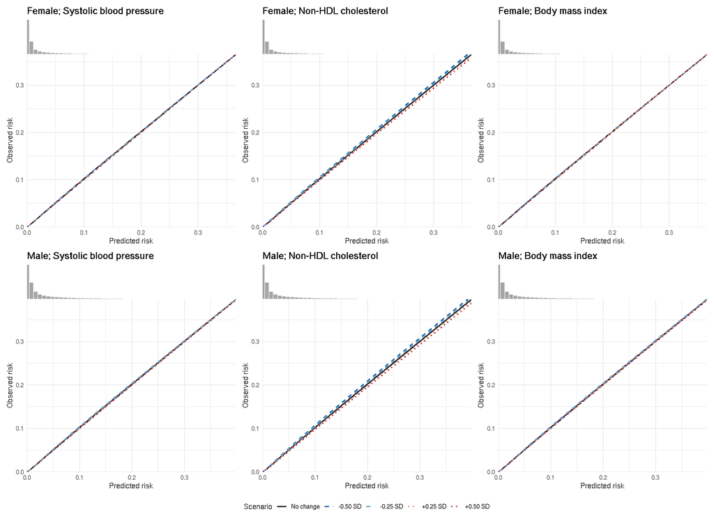

# 3 Adjustment values

The following table reports the observed standard deviation used to set each delta, the resulting change in the predictor's original units, and the number of values originally missing. The mean before and after adjustment is calculated only among people whose value were missing (i.e. observed values are not included in this calculation).

MNAR adjustments applied to originally missing values

| Gender | Variable | Scenario | Originally missing, N | Originally missing, % | Observed SD | Shift in original units | Mean before | Mean after | Minimum after | Maximum after |
| --- | --- | --- | --- | --- | --- | --- | --- | --- | --- | --- |
| Female | Systolic blood pressure | -0.50 SD | 2042261 | 20.630 | 16.530 | -8.265 | 118.076 | 109.811 | 62.735 | 200.735 |
| Female | Systolic blood pressure | -0.25 SD | 2042261 | 20.630 | 16.530 | -4.132 | 118.076 | 113.944 | 66.868 | 204.868 |
| Female | Systolic blood pressure | +0.25 SD | 2042261 | 20.630 | 16.530 | 4.132 | 118.076 | 122.208 | 75.132 | 213.132 |
| Female | Systolic blood pressure | +0.50 SD | 2042261 | 20.630 | 16.530 | 8.265 | 118.076 | 126.341 | 79.265 | 217.265 |
| Female | Non-HDL cholesterol | -0.50 SD | 8209259 | 82.925 | 1.111 | -0.556 | 3.300 | 2.745 | -0.156 | 18.524 |
| Female | Non-HDL cholesterol | -0.25 SD | 8209259 | 82.925 | 1.111 | -0.278 | 3.300 | 3.023 | 0.122 | 18.802 |
| Female | Non-HDL cholesterol | +0.25 SD | 8209259 | 82.925 | 1.111 | 0.278 | 3.300 | 3.578 | 0.678 | 19.358 |
| Female | Non-HDL cholesterol | +0.50 SD | 8209259 | 82.925 | 1.111 | 0.556 | 3.300 | 3.856 | 0.956 | 19.636 |
| Female | Body mass index | -0.50 SD | 3583505 | 36.199 | 5.420 | -2.710 | 25.342 | 22.632 | 15.291 | 44.282 |
| Female | Body mass index | -0.25 SD | 3583505 | 36.199 | 5.420 | -1.355 | 25.342 | 23.987 | 16.646 | 45.637 |
| Female | Body mass index | +0.25 SD | 3583505 | 36.199 | 5.420 | 1.355 | 25.342 | 26.698 | 19.356 | 48.347 |
| Female | Body mass index | +0.50 SD | 3583505 | 36.199 | 5.420 | 2.710 | 25.342 | 28.053 | 20.711 | 49.702 |
| Male | Systolic blood pressure | -0.50 SD | 3972552 | 41.769 | 15.490 | -7.745 | 125.259 | 117.514 | 63.255 | 201.255 |
| Male | Systolic blood pressure | -0.25 SD | 3972552 | 41.769 | 15.490 | -3.873 | 125.259 | 121.387 | 67.127 | 205.127 |
| Male | Systolic blood pressure | +0.25 SD | 3972552 | 41.769 | 15.490 | 3.873 | 125.259 | 129.132 | 74.873 | 212.873 |
| Male | Systolic blood pressure | +0.50 SD | 3972552 | 41.769 | 15.490 | 7.745 | 125.259 | 133.004 | 78.745 | 216.745 |
| Male | Non-HDL cholesterol | -0.50 SD | 7880206 | 82.855 | 1.107 | -0.553 | 3.549 | 2.996 | -0.153 | 20.047 |
| Male | Non-HDL cholesterol | -0.25 SD | 7880206 | 82.855 | 1.107 | -0.277 | 3.549 | 3.273 | 0.123 | 20.323 |
| Male | Non-HDL cholesterol | +0.25 SD | 7880206 | 82.855 | 1.107 | 0.277 | 3.549 | 3.826 | 0.677 | 20.877 |
| Male | Non-HDL cholesterol | +0.50 SD | 7880206 | 82.855 | 1.107 | 0.553 | 3.549 | 4.103 | 0.953 | 21.153 |
| Male | Body mass index | -0.50 SD | 4474478 | 47.046 | 4.571 | -2.285 | 25.434 | 23.149 | 15.715 | 44.705 |
| Male | Body mass index | -0.25 SD | 4474478 | 47.046 | 4.571 | -1.143 | 25.434 | 24.292 | 16.858 | 45.847 |
| Male | Body mass index | +0.25 SD | 4474478 | 47.046 | 4.571 | 1.143 | 25.434 | 26.577 | 19.143 | 48.133 |
| Male | Body mass index | +0.50 SD | 4474478 | 47.046 | 4.571 | 2.285 | 25.434 | 27.720 | 20.286 | 49.275 |